# HP2_Scroppo

Author

Noah Scroppo

### Importing Data

```r
#Importing Libraries & Data

library(tidyverse)
library(kableExtra)
library(gt)
library(readr)
library(dplyr)
library(leaflet)
online_foods <- read_csv("onlinefoods.csv")
write_rds(online_foods, "online_foods.rds")
```

## Analyzing Online Food Ordering Habits and Characteristics

This is a comprehensive data report and analysis covering the “Online Food Dataset” from Kaggle.com.

## Introduction and Topics to Explore

The modern convenience of online food services has become a significant aspect of consumer’s lifestyles, influencing dining habits and preferences across demographics. This report delves into the onlinefoods.csv dataset, which comprises data on individuals’ usage and feedback regarding online food services. This dataset contains information collected from an online food ordering platform over a period of time. Through comprehensive data analysis, this report aims to unearth trends and correlations that might inform business strategies for service providers and contribute to better consumer experiences.

Topics I will be exploring:

1. Demographic Influence: How do age and gender influence the feedback and usage frequency of online food services? Is there a noticeable difference in the way different demographic groups perceive the quality of service?
2. Socioeconomic Impact: Does a person’s occupation and income level affect their likelihood to use and positively review online food services? How do educational qualifications correlate with the types of feedback given?
3. Geographical Trends: Are there specific areas where feedback tends to be more positive or negative?
4. Family Dynamics: Does family size influence the frequency of using online food services? How does the family structure relate to overall satisfaction with these services?

### Cleaning The Data

```r
online_foods <- read_rds("online_foods.rds")

#Dropping unnamed column
online_foods_clean <- online_foods |> select(-"...13")

#Rename Column for Clarity
online_foods_clean <- online_foods_clean |> rename(
  "Delivered" = "Output"
)

#Add a new row unique identifier
online_foods_clean <- online_foods_clean |> mutate(id = row_number()) |>
  select(id, everything())
#Checking Variable Typebus
str(online_foods)
```

## A Data Dictionary to explain variables in the data set:

```r
df_dictionary <- tibble::tribble(
  ~variable, ~description,
  "ID", "Unique Identifier",
  "Age:",  "Age of the customer",
"Gender:", "Gender of the customer",
"Marital Status:", "Marital status of the customer",
"Occupation:", "Occupation of the customer",
"Monthly Income:", "Monthly income of the customer",
"Educational Qualifications:", "Educational qualifications of the customer",
"Family Size:", "Number of individuals in the customer's family",
"Latitude:", "Latitude of the customer's location",
"Longitude:", "Longitude of the customer's location",
"Pin Code:", "Pin code of the customer's location",
"Delivered:", "Current status of the order (e.g., pending, confirmed, delivered)",
"Feedback:", "Feedback provided by the customer after receiving the order")

df_dictionary |>
  gt() |>
  opt_row_striping() |>
  opt_stylize(style = 5)
```

| variable | description |
| --- | --- |
| ID | Unique Identifier |
| Age: | Age of the customer |
| Gender: | Gender of the customer |
| Marital Status: | Marital status of the customer |
| Occupation: | Occupation of the customer |
| Monthly Income: | Monthly income of the customer |
| Educational Qualifications: | Educational qualifications of the customer |
| Family Size: | Number of individuals in the customer's family |
| Latitude: | Latitude of the customer's location |
| Longitude: | Longitude of the customer's location |
| Pin Code: | Pin code of the customer's location |
| Delivered: | Current status of the order (e.g., pending, confirmed, delivered) |
| Feedback: | Feedback provided by the customer after receiving the order |

There are 388 participants that we have data for in this study.

## Demographic Influence

```r
age_stats <- online_foods_clean |>
  summarise(Max_Age = max(Age, na.rm = TRUE),
            Min_Age = min(Age, na.rm = TRUE),
            Mean_Age = mean(Age, na.rm = TRUE))


age_stats |> gt()
```

| Max_Age | Min_Age | Mean_Age |
| --- | --- | --- |
| 33 | 18 | 24.62887 |

The first thing I calculated to begin my analysis was create a dataframe that looks at the ages of all the participants. We see the results above. Then what I did was analyze the feedback by age to see if that had an effect. We see that younger people did respond with more positive feedback than people older than the average age in this study.

Then I was curious to see how gender affected feedback so I created a separate dataframe to analyze this. Looking at the graph we can see that similar percent of each gender voted positively and negatively so this does not tell us too much.

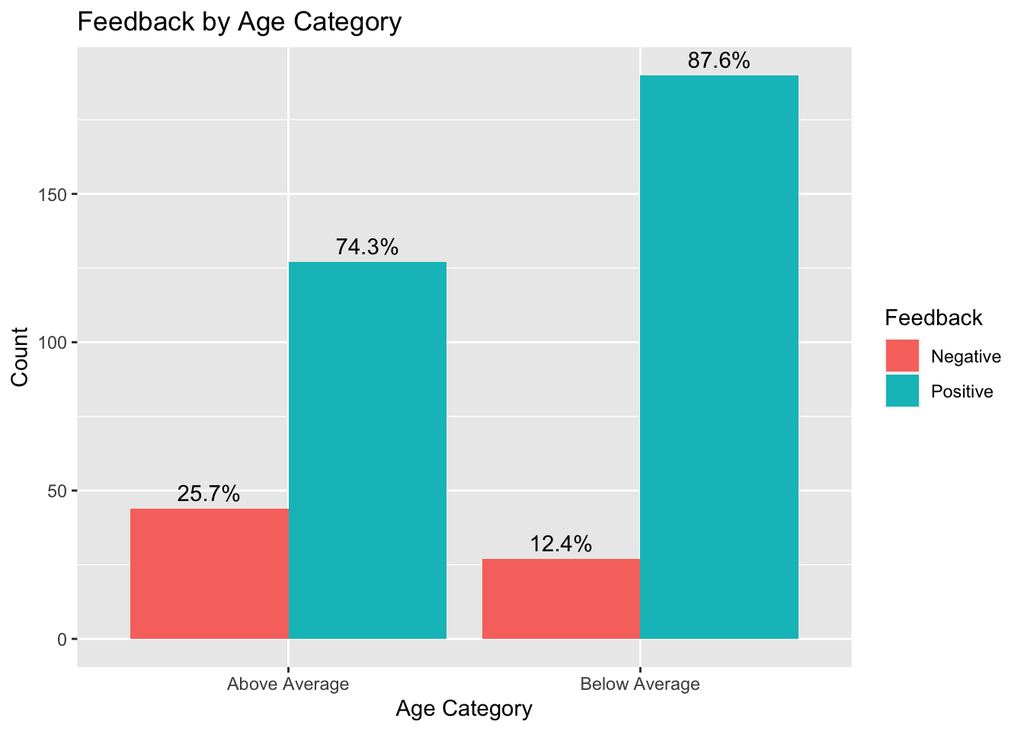

```r
online_foods_clean <- online_foods_clean %>%
  mutate(Age_Category = if_else(Age > age_stats$Mean_Age, "Above Average", "Below Average"))

age_feedback <- online_foods_clean %>%
  group_by(Age_Category, Feedback) %>%
  summarise(Count = n(), .groups = 'drop') %>%
  group_by(Age_Category) %>%
  mutate(Total = sum(Count),
         Percent = (Count / Total) * 100)

# Visualizing the feedback by Age Category with percentage
ggplot(age_feedback, aes(x = Age_Category, y = Count, fill = Feedback)) +
  geom_bar(stat = "identity", position = position_dodge(width = 0.9)) +
  geom_text(aes(label = sprintf("%.1f%%", Percent)), vjust = -0.5, position = position_dodge(width = 0.9)) +
  labs(title = "Feedback by Age Category", x = "Age Category", y = "Count")
```

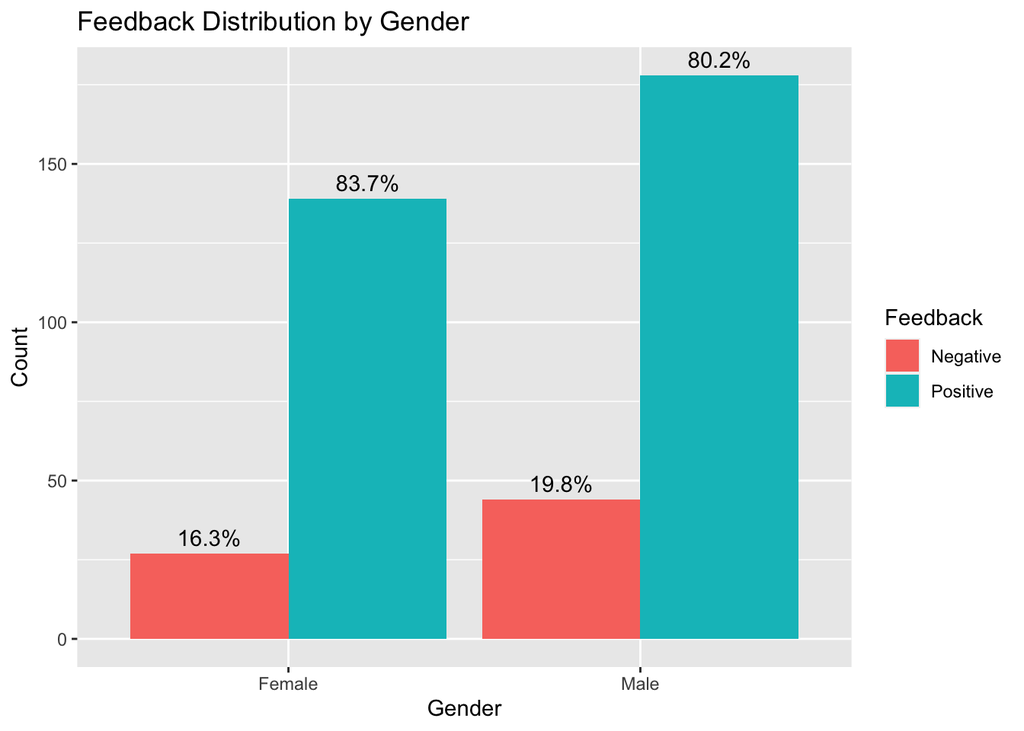

```r
gender_feedback_distribution <- online_foods_clean %>%
  group_by(Gender, Feedback) %>%
  summarise(Count = n(), .groups = 'drop') %>%
  group_by(Gender) %>%
  mutate(Total = sum(Count),  # Calculate the total feedback count per gender
         Percent = (Count / Total) * 100)  # Calculate percentage within each gender group

# Visualizing gender feedback distribution with percentages
ggplot(gender_feedback_distribution, aes(x = Gender, y = Count, fill = Feedback)) +
  geom_bar(stat = "identity", position = position_dodge(width = 0.9)) +
  geom_text(aes(label = sprintf("%.1f%%", Percent)), vjust = -0.5, position = position_dodge(width = 0.9)) +
  labs(title = "Feedback Distribution by Gender", x = "Gender", y = "Count")
```

## Socioeconomic Impact

The next set of questions I wanted to investigate related to the socioeconomic levels of the participants in the data. I started with splitting up the various income levels of each of the participants into the 5 segments it was already broken up with. Within this, I also split each income level by occupation to observe any deeper effects. We can see that employees with an income level below $10,000 reported the highest percent of negative feedback. Actually, that income level group reported the most collective negative feedback. Interestingly, students at three different income levels had 0% negative feedback to give. Assumptions could be made that the added fees of using online food ordering apps could be a cause of people at a lower income level rating the platform more negatively.

The next graph was just to briefly look at how weighted the different educational levels were responding to the feedback. We see that graduate and post-graduate participants made up most of the data.

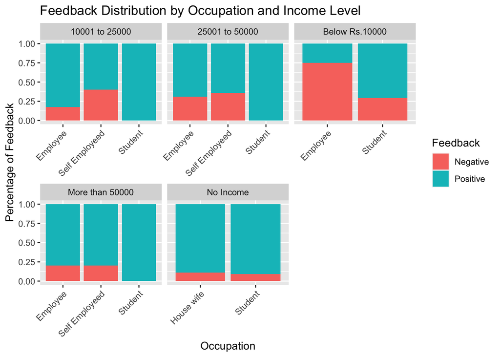

```r
occupation_income_feedback <- online_foods_clean %>%
  group_by(Occupation, `Monthly Income`, Feedback) %>%
  summarise(Count = n(), .groups = 'drop') %>%
  mutate(Total = sum(Count), Percent = (Count / Total) * 100) %>%
  ungroup() %>%
  arrange(desc(Percent))

# Visualizing feedback by occupation and income level
ggplot(occupation_income_feedback, aes(x = Occupation, y = Percent, fill = Feedback)) +
  geom_bar(stat = "identity", position = position_fill(reverse = TRUE)) +
  facet_wrap(~`Monthly Income`, scales = "free_x") +
  theme(axis.text.x = element_text(angle = 45, hjust = 1)) +
  labs(title = "Feedback Distribution by Occupation and Income Level", x = "Occupation", y = "Percentage of Feedback")
```

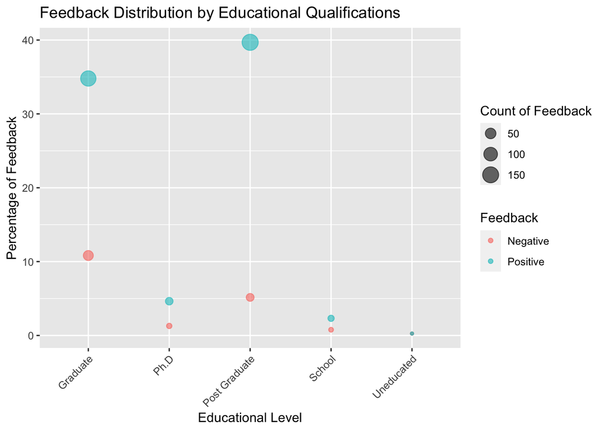

```r
education_feedback <- online_foods_clean %>%
  group_by(`Educational Qualifications`, Feedback) %>%
  summarise(Count = n(), .groups = 'drop') %>%
  mutate(Total = sum(Count), Percent = (Count / Total) * 100) %>%
  ungroup()

# Visualizing the correlation between education and feedback
ggplot(education_feedback, aes(x = `Educational Qualifications`, y = Percent, size = Count, color = Feedback)) +
  geom_point(alpha = 0.6) +
  theme(axis.text.x = element_text(angle = 45, hjust = 1)) +
  labs(title = "Feedback Distribution by Educational Qualifications", x = "Educational Level", y = "Percentage of Feedback", size = "Count of Feedback")
```

## Geographical Trends

Next I looked at how geographical tends influenced feedback. It can be seen that this study was mostly conducted in the city of Bengaluru, India. This was interesting to me since it was never mentioned on the website where this study was conducted. Looking a little deeper, we see a lot of positive feedback was located in the heart of the city and most of the negative feedback was on the outskirts. It can be assumed this is because maybe the houses and restaurateurs are more accessible and easier to locate and the ones on the outskirts could be difficult to navigate.

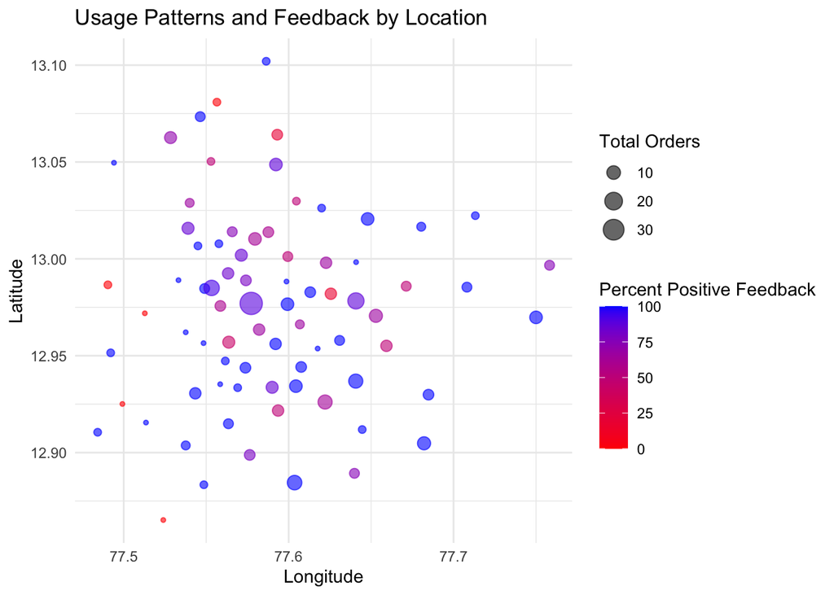

```r
location_summary <- online_foods_clean %>%
  group_by(latitude, longitude) %>%
  summarise(
    Total_Orders = n(),
    Positive_Feedback = sum(Feedback == "Positive", na.rm = TRUE),
    Percent_Positive = (Positive_Feedback / Total_Orders) * 100,
    .groups = 'drop'
  )

ggplot(location_summary, aes(x = longitude, y = latitude, size = Total_Orders, color = Percent_Positive)) +
  geom_point(alpha = 0.6) +
  scale_color_gradient(low = "red", high = "blue") +
  labs(
    title = "Usage Patterns and Feedback by Location",
    x = "Longitude",
    y = "Latitude",
    color = "Percent Positive Feedback",
    size = "Total Orders"
  ) +
  theme_minimal()
```

```r
leaflet(data = location_summary) %>%
  addTiles() %>%
  addCircleMarkers(
    lng = ~longitude, lat = ~latitude,
    radius = ~sqrt(Total_Orders) * 2,
    color = ~colorNumeric(palette = "RdBu", domain = Percent_Positive)(Percent_Positive),
    popup = ~paste("Total Orders:", Total_Orders, "<br>",
                   "Positive Feedback:", Positive_Feedback, "<br>",
                   "Percent Positive:", sprintf("%.2f%%", Percent_Positive))
  ) %>%
  addLegend("bottomright",
            pal = colorNumeric(palette = "RdBu", domain = NULL),
            values = ~Percent_Positive,
            title = "Percent Positive Feedback",
            opacity = 1)
```

[interactive chart not shown]

## Family Dynamics

Lastly, I aimed to see how family dynamics influenced the feedback in this data. Starting with positive feedback, there is not really a visible trend to be extracted here but the highest percent was a family size of 4. Shifting to the negative feedback, the lowest percent was actually the family size of 4. The highest in this category was a family size of 1. This is interesting to me and something I would of liked to further analyze with more data.

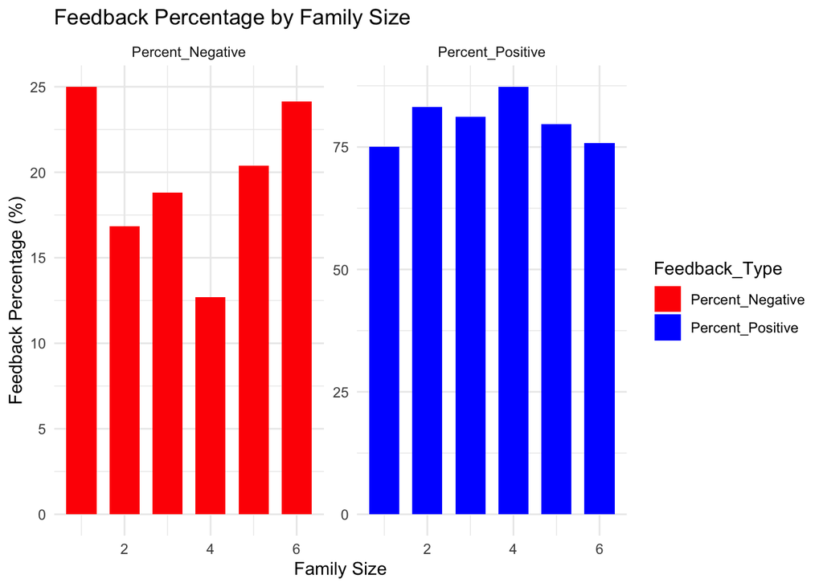

```r
family_size_summary <- online_foods_clean %>%
  group_by(`Family size`) %>%
  summarise(
    Total_Orders = n(),
    Positive_Feedback = sum(Feedback == "Positive", na.rm = TRUE),
    Negative_Feedback = sum(Feedback == "Negative", na.rm = TRUE),
    Percent_Positive = (Positive_Feedback / Total_Orders) * 100,
    Percent_Negative = (Negative_Feedback / Total_Orders) * 100,
    .groups = 'drop'
  )

family_size_long <- family_size_summary %>%
  pivot_longer(cols = c("Percent_Positive", "Percent_Negative"),
               names_to = "Feedback_Type",
               values_to = "Percentage")


ggplot(family_size_long, aes(x = `Family size`, y = Percentage, fill = Feedback_Type)) +
  geom_col(position = "dodge", width = 0.7) +
  facet_wrap(~Feedback_Type, scales = "free_y") +
  scale_fill_manual(values = c("Percent_Positive" = "blue", "Percent_Negative" = "red")) +
  labs(title = "Feedback Percentage by Family Size",
       x = "Family Size",
       y = "Feedback Percentage (%)") +
  theme_minimal()
```

## Conclusion

In conclusion, this wraps up my data analysis on this csv file. I learned a lot while doing this analysis and would love to see a study like this conducted in my city. The most enlightening analysis was the income level and occupation analysis and the geographical map was really fun to code.